# Introduction to Long-reads Bulk RNA-Seq data analysis

Cancer Genomics & Transcriptomics Course, EMBL-EBI

Alexey Larionov

16 May 2025

# 1. Introduction

This session is aimed at providing an initial practical experience with long-reads RNA-Seq data analysis. Long-reads sequencing technology is changing at a very fast pace. So do the tools and algorithms for the data analysis. Many different tools exist for each task. Often the tools are technology-specific (i.e. Nanopore tools do not work for PacBio and *vice versa*).

Tools for this session were selected to illustrate the main steps required for **QC**, **DGE** (Differential Gene Expression) and **DTU** (Differential Transcript Usage) analyses, using Nanopore cDNA sequencing data as an example.

This document shows only selected elements of the code. The full code is provided in the accompanying scripts.

## 1.1 VM specifications and working folder

The **wf-transcriptomes** workflow, which we will use during this session, requires at least 32GB RAM. Many tools used in this session allow parallelization and multiprocessing. In most cases the scripts are written to request 14-16 threads (CPUs). Make sure that your VM has the required resources.

Explore the **~/bulk-rnaseq/long-reads** folder in your home directory. It should contain sub-folders for **scripts**, **data** and **results**. There are no results within the folder yet. However, it is expected that you may make some during this session.

A separate folder is created for **wf-transcriptomes** pipeline. For now, it only contains the source data. Results will be added to this folder after the **wf-transcriptomes** run.

There is a copy of the **~/bulk-rnaseq/long-reads** folder on the **penelopeCloud**. It contains copies of the source data, scripts *and expected results*. You may copy files from **penelopeCloud** to your home folder, if needed. However, don’t run, change or remove files directly on **penelopeCloud** !

## 1.2 Intended way of working through the practical session

Like during the *short-reads* session you are given scripts for all tasks. Working on a task, you start with a brief orientation, then you launch the script, and further explore the script’s content while it is running.

Some scripts may take 5-10 min to complete. For the duration of such scripts, you may explore the output of the previous scripts, look at the expected result of the running script (provided on **penelopeCloud**), or review the examples of **Illumina**, **ONT** and **PacBio** RNA-seq data in IGV (using the provided BAM files, see Section 2).

## 1.3 SG-NEx study

Data used for **QC** and **Pre-processing** sections of this practical was generated by the **SQ-NEx** study:

- https://www.nature.com/articles/s41592-025-02623-4

Briefly, the study sequenced RNA from several cancer cell lines to compare different RNA-seq options available in Nanopore: PCR-based cDNA, direct cDNA and direct-RNA sequencing. Samples selected for this session include PCR-based cDNA data from **H9** (embryonic stem cells) and **HEYA8** (ovarian adenocarcinoma) cell lines:

| ID | Cell.line | SGNex.sample.info |
| --- | --- | --- |
| HEYA8_14 | HEYA8 | SGNex_HEYA8_cDNA_replicate1_run4 |
| HEYA8_24 | HEYA8 | SGNex_HEYA8_cDNA_replicate2_run4 |
| HEYA8_33 | HEYA8 | SGNex_HEYA8_cDNA_replicate3_run3 |
| H9_24 | H9 | SGNex_H9_cDNA_replicate2_run4 |
| H9_34 | H9 | SGNex_H9_cDNA_replicate3_run4 |
| H9_44 | H9 | SGNex_H9_cDNA_replicate4_run4 |

All selected samples were sequenced on the same day (2021-03-30) using the same Nanopore machine and flowcell (PromethION PRO002). The same basecaller (guppy-3.2.10-GIS) was used for all samples, and they had been prepared using the same library kit (SQK-PCB109). Please note that this data was created 4 years ago, so it may not represent the latest Nanopore sequencing and basecalling quality.

You may see more details about **SQ-NEx study** at

- https://github.com/GoekeLab/sg-nex-data

# 2. Long- and short- read RNA-Seq BAMs to explore

There are examples of **Illumina**, **ONT** and **PacBio** BAM files in **…/bulk-rnaseq/short-reads/bam** and **…/bulk-rnaseq/long-reads/bams** folders. You may use these files to compare different types of RNA-seq data in IGV (use GRCh38 gemome, then Menu > File > Load from file…) . To reduce the file sizes, some of the BAM files had been sub-sampled. So, it is better to explore highly abundant genes, such as ACTB:

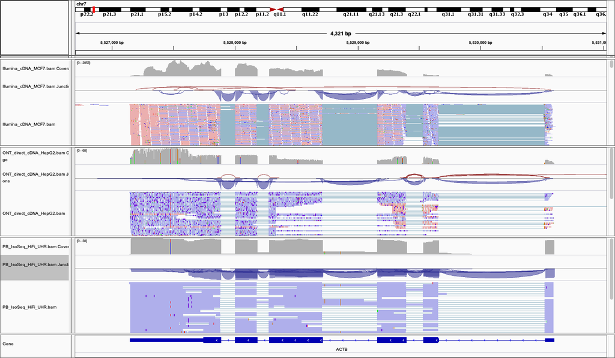

Which of the technologies has the highest error rate ?  
Does the high error rate prevent the full-length transcript identification ?

# 3. Evaluate ONT data with *NanoPack*

**NanoPack** is a set of tools for quality control (QC) and filtering of Nanopore *fastq* files; it includes:

- **NanoPlot** : QC for a single *fastq* file
- **NanoComp** : comparison of quality metrics between *fastq* files
- **chopper** : filtering of Nanopore *fastq* by quality metrics
- and some other tools : https://github.com/wdecoster/nanopack

The **NanoPlot** and **NanoComp** tools are used by the scripts provided in **…/long-reads/scripts/s01_nanopack_qc** folder.

Explore and run these scripts. Then review the selected output files mentioned below.

## 3.1 QC single *fastq* file with *NanoPlot*

**NanoPlot** can be started by the following code:

```bash
NanoPlot \
  --fastq "${input_fq_gz}" \
  --threads 14 \
  --drop_outliers \
  --outdir "${output_folder}"
```

See more details in the provided script. The script should run for 3-5 min. The full list of **NanoPlot** options is described at its GitHub page: https://github.com/wdecoster/NanoPlot

The output folder will contain many figures and a summary file **NanoPlot-report.html**. Open the summary file and find the plot showing **Read length vs Average read quality using kernel density**. I hope that in your data it doesn’t look like this:

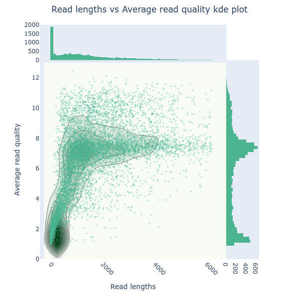

Does the figure above show raw data or data already filtered by read quality?  
Why have I suggested that this is not a good quality sample?

**Optional question:**  
What line of your **NanoPlot** script activates Nanoplot environment? Why this line is needed?

## 3.2 Compare multiple *fastq* files with *NanoComp*

Comparison of the multiple fastqc files could be done by **NanoComp** (again, see details in the script):

```bash
NanoComp \
--fastq "${HEYA8_14}" "${HEYA8_24}" "${HEYA8_33}" "${H9_24}" "${H9_34}" "${H9_44}" \
--names HEYA8_14 HEYA8_24 HEYA8_33 H9_24 H9_34 H9_44 \
--threads 14 \
--outdir "${output_folder}"
```

In the above code snippet, what is contained in **${HEYA8_14}** variable ?

The full list of **NanoComp** options is available on its GitHub page: https://github.com/wdecoster/nanocomp

The script should complete within 7-10 min. The output folder will contain many figures and a summary file **NanoComp-report.html**. Open the summary file and find the plot comparing average base call quality scores, which may look like this:

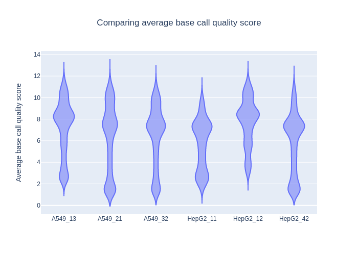

The figure above shows results for samples for A539 and HepG2 cells from SG-NEX study that are not included into your practical session. Of course, your results should look slightly different.

Was there any read with average base quality at least 20 in your data? Make a rough estimate for the proportion of reads that would be retained after filtering by average base quality 10.

Find the plot showing *number of reads per sample*. What was the largest number of reads amongst the studied samples? Note that the files had been thinned to 10% of their original size. So, the original read counts were much higher.

# 4. Pre-processing of cDNA Nanopore data

After QC, we may need to filter and trim the data to remove bad quality reads. A generic filtering usually include removing reads with short length and a low average quality. In our practical we will use Nanopack’s tool called **chopper** for this.

Then the cDNA data should be additionally pre-processed to make sure that we only retain **“full length”** reads (containing both **SSP** and **VNP** primers), and orient the reads in a way representing the coding strand (again, based on the sequences of **SSP** and **VNP** primers - see the lecture). Then the primers should be chopped away. The Oxford Nanopore tool that does it is called **Pychopper**.

What a confusing naming! Remember: the Nanopack’s **chopper** and the Nanopore’s **Pychopper** are different tools!

Scripts for this part of the parctical session are located in the **…/long-reads/scripts/s02_nanopore_preprocessing** folder.

## 4.1 Filter fastq file with *chopper*

```bash
gunzip -c "${input_fq_gz}" | chopper -q 10 -l 500 | gzip > "${output_fq_gz}"
```

Note that at present **chopper** does not recognize *gzipped* files. So it has to be wrapped in gunzip/gzip to process such files.

The full list of filters and options for **chopper** is available at its GitHub page:

- https://github.com/wdecoster/chopper

The script should complete within 3-5 min. It will produce a *fastq* file containing only reads that passed the filter(s).

What threshold for quality filtering was used in the above code fragment?

## 4.2 Trim and orient cDNA reads with *Pychopper*

**Pychopper** is a tool to identify, orient and trim **full-length** Nanopore cDNA reads:

- https://github.com/epi2me-labs/pychopper

It detects **SSP** (Strand Switching Primer) and **VNP** (the anchored oligo-dT VN Primer) in the reads. Reads that contain both primers in a correct orientation are considered **full-reads**. The primer sequences can be used to derive the orientation of **full-reads**: e.g. **SSP** should be at the 5’ end and reverse-complement of **VNP** at the 3’ end of the coding strand. Because of the high error rate in the raw Nanopore data (especially in the data generated some years ago) **Pychopper** has to employ complex approximation algorithm to detect the primer sequences. In addition, **Pychopper** accounts for the distance between the putative primers.

Importantly, for **Pychopper** to work the primer trimming should be switched OFF during the *basecalling* (i.e. when *fastq* files are generated from the raw *fast5* files).

The output of Pychopper includes

- *fastq* with trimmed and properly oriented **full-length** reads
- *fastq*-s with **failed** and “**rescued**” reads
- *tsv* and *pdf* files with read counts and plots

This code is used for running **Pychopper** in our script:

```bash
pychopper \
-t 16 \
-m edlib \
-S "${statistics_tsv}" \
-r "${report_pdf}" \
-u "${unclassified_fq}" \
-w "${rescued_fq}" \
"${input_fq}" \
"${full_length_fq}"
```

Does the command above use parallelisation (multithreading)? If yes, how many cores have been requested?

**Optional questions:**

- What **-m** parameter does in the above code?
- Can Pychopper detect UMIs?

*(you may look for answers in Pychopper documentation on GitHub)*

These are examples of the plots from the **Pychopper’s** summary *pdf* file :

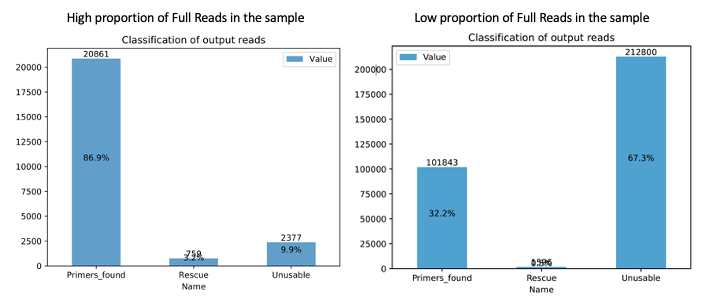

The figure above shows examples of a good (on the left) and a bad (on the right) samples. Is the sample given to you for this practical session good or bad?

A low proportion of **full reads** might be rescued by increasing the sensitivity of the algorithm that identifies primers (adding parameter **-q** to the above command, see details in the **Pychopper** GitHub page). However, this may reduce the specificity of primer detection. In the recent versions of **Pychopper** the **-q** parameter is selected automatically using a small sub-set of reads, before processing the entire file.

# 5. Nanopore *wf-transcriptomes* pipeline

## 5.1 Pipelines / Workflows

Till now we considered data analysis one step at a time e.g.: **QC**, then **filtering**, then **trimming** etc.  
We have not discussed yet what is required to make a **pipeline** out of multiple steps:

- Design the conceptual **workflow** that puts the right tools in the right order.
- Install and configure all the dependencies (i.e. the tools and resources required for analysis).
- Align outputs of the upstream tools with input requirements of the downstream tools.
- Arrange the locations of the source data, interim files and results.
- Write scripts that assemble all the pieces together, log and parallelize the computation.
- etc.

In addition to understanding the bioinformatics tasks and tools, making a pipeline may require advanced IT and programming skills. In an attempt to take this burden out of the bio-medical researchers (and to avoid many amateurish mistakes) both **Nanopore** and **PacBio** made an effort to provide entire functional **pipelines** (also called **workflows**), in addition to the separate tools and conceptual guidance. Making pipelines is becoming more and more popular in bioinformatics community.

## 5.2 Workflow Management Systems

Several **workflow management systems** have been developed for building bioinformatics pipelines including **Snakemake** (https://snakemake.readthedocs.io/en/stable), **Cromwell** (https://cromwell.readthedocs.io/en/stable) and **Nextflow** (https://www.nextflow.io/). Some years ago it looked like **Nanopore** preferred **Snakemake** and **PacBio** preferred **Cromwell** for their pipelines. However, recently it seems that **Nextflow** is gaining popularity, not least because of the **NF-Core**: a large repository of the **Nextflow** bioinformatics pipelines (https://nf-co.re/pipelines/).

In this practical you will try a **Nextflow** pipeline, which was developed by Oxford Nanopore for quantitative RNAseq analysis:

- https://github.com/epi2me-labs/wf-transcriptomes

## 5.3 *wf-transcriptomes* pipeline overview

The first (now deprecated) Nanopore’s pipeline for quantitative RNAseq analysis was based on the paper of Love et al 2018 ( https://f1000research.com/articles/7-952/v3 ). It included alignment with **minimap2** against a reference transcriptome, followed by counts with **Salmon**, differential genes expression (**DGE**) with **edgeR** and differential transcripts usage (**DTU**) analysis using R packages **DEXSeq** and **stageR**. That pipeline used **Snakemake** workflow manager. Recently it has been substituted by the **wf-transcriptomes** pipeline, which uses **Nextflow**.

Currently the **wf-transcriptomes** pipeline includes the following functionality:

- **Identifying RNA transcripts** (using either cDNA or direct RNA reads)
- Making reference-aided **transcriptome assembly**
- **Annotating** the assembled transcripts
- Differential gene expression (**DGE**) analysis
- Differential transcript usage (**DTU**) analysis

Conceptually, **DGE** part of this workflow is similar to the **DGE** analysis that we discussed for *short-reads* analysis. The main differences from the *short-reads* analysis include:

- using **minimap2** for mapping, instead of performing quasi-mapping by **Salmon** itself
- using **edgeR** instead of **DESeq2** package for actual differential expression analysis

## 5.4 Running *wf-transcriptomes* pipeline

The instructions below will guide you through the main steps needed to run the pipeline during this practical session. Many more technical details are available in the pipeline’s GitHub repository (https://github.com/epi2me-labs/wf-transcriptomes).

### 5.4.1 Review the source data

Go to **…/long-reads/wf-transcriptomes/source_data** folder:

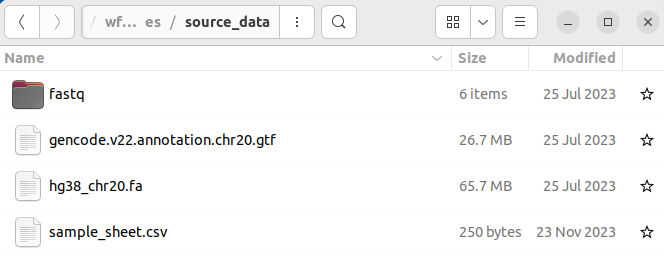

You can see there **(i)** the sample sheet, **(ii)** the folder with *fastq* files and **(iii)** various resources prepared for the pipeline.

#### Sample sheet

contains description of the samples:

| barcode | sample_id | alias | condition |
| --- | --- | --- | --- |
| barcode01 | sample01 | sample01 | control |
| barcode02 | sample02 | sample02 | control |
| barcode03 | sample03 | sample03 | control |
| barcode04 | sample04 | sample04 | treated |
| barcode05 | sample05 | sample05 | treated |
| barcode06 | sample06 | sample06 | treated |

#### The folder with **fastq** files

In this case, the files are organised into sub-folders according to their barcodes, provided in the sample sheet above. The **fastq** files were sliced, containing only Chr20. This allows running the entire workflow within ~15 min.

#### The resources

In this case you can see the refernce genome (**hg38** chromosome 20) and the genome annotations (the gencode 22 **gtf** file).

### 5.4.2 Run the pipeline

Go to **…/long-reads/scripts/s03_wf_transcriptomes** folder. Review and run the script:

```bash
./run_wf_transcriptomes.sh &> run_wf_transcriptomes.log # Start the pipeline recording output to the log
```

The script content should look like this:

```bash
working_folder=".../long-reads/wf-transcriptomes"
cd "${working_folder}"

nextflow run epi2me-labs/wf-transcriptomes \
--de_analysis \
--direct_rna \
--fastq  source_data/fastq \
--sample_sheet source_data/sample_sheet.csv \
--ref_genome source_data/hg38_chr20.fa \
--ref_annotation source_data/gencode.v22.annotation.chr20.gtf \
--minimap2_index_opts '-k 15' \
-profile singularity
```

The meaning of the pipeline-launching command is the following:

- it instructs **nextflow** to start the **epi2me-labs/wf-transcriptomes** workflow
- instructs to perform differential expression analysis (**de_analysis**)
- informs about the type of analysed RNAseq data (**direct_rna**)
- provides location of the folder with source **fastq** files
- provides location of the **sample sheet**
- provides location of the **reference genome**
- provides location of the **genome annotation file**
- sets a specific parameter for **minimap2**
- **profile** line instructs the workflow to use **Singularity** (instead of Docker)

Many more settings, which could be used with this workflow, are described in the workflow’s GitHub page.

### 5.4.3 Review the results

During the run, the workflow reports progress to the log (or to the terminal, if you don’t record the output to the log). The entire workflow should complete within ~10-15 min. After the completion of the workflow go to the **…/long-reads/wf-transcriptomes** folder.

New folders should be created by the pipeline during the run.

The **work** folder (and possibly some hidden files and folders, created by **Nextflow** workflow manager) should contain technical information that may be helpful for debugging, if something goes wrong.

The actual outputs of the analysis should be available in the folder called **output**:

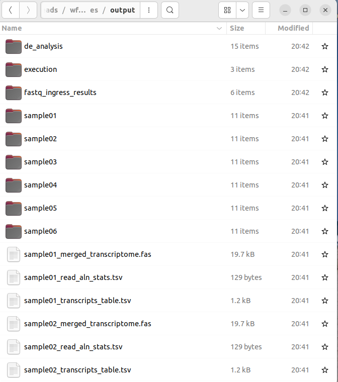

You can see that the output folder includes multiple files and folders with results for each requested step of the analysis. Most likely, you will not have time to explore all the output files and folders during our practical session. So, you may first focus on the files and folders mentioned below.

#### Workflow summary report

In the output folder, find the file called **wf-transcriptomes-report.html**, open and explore it:

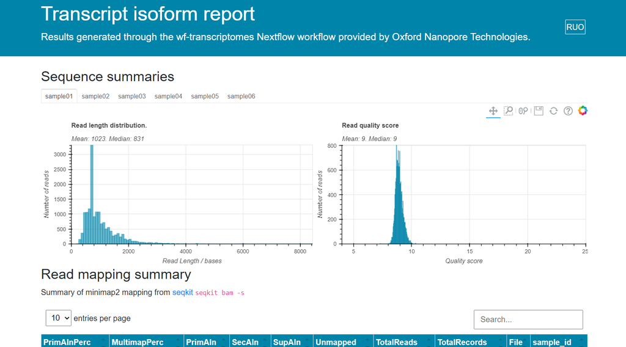

After some technical information, you may find the tables with results of differential expression analysis, showing **Log2FC** and **padj** for all genes and transcripts:

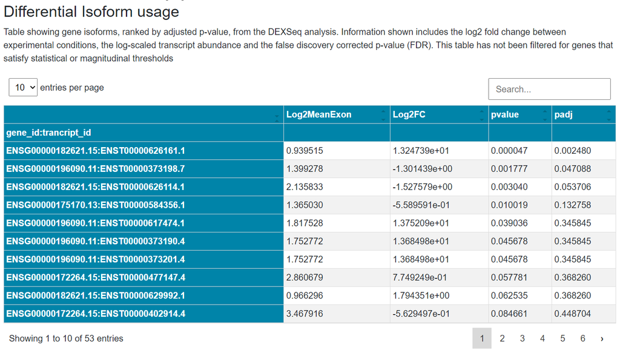

Also the report contains MA plots. Unfortunately, because of the very small number of genes in the thinned slice of data used for this practical session, the MA plots in your report will not look very informative. If the data was larger, the report might show MA plots like this:

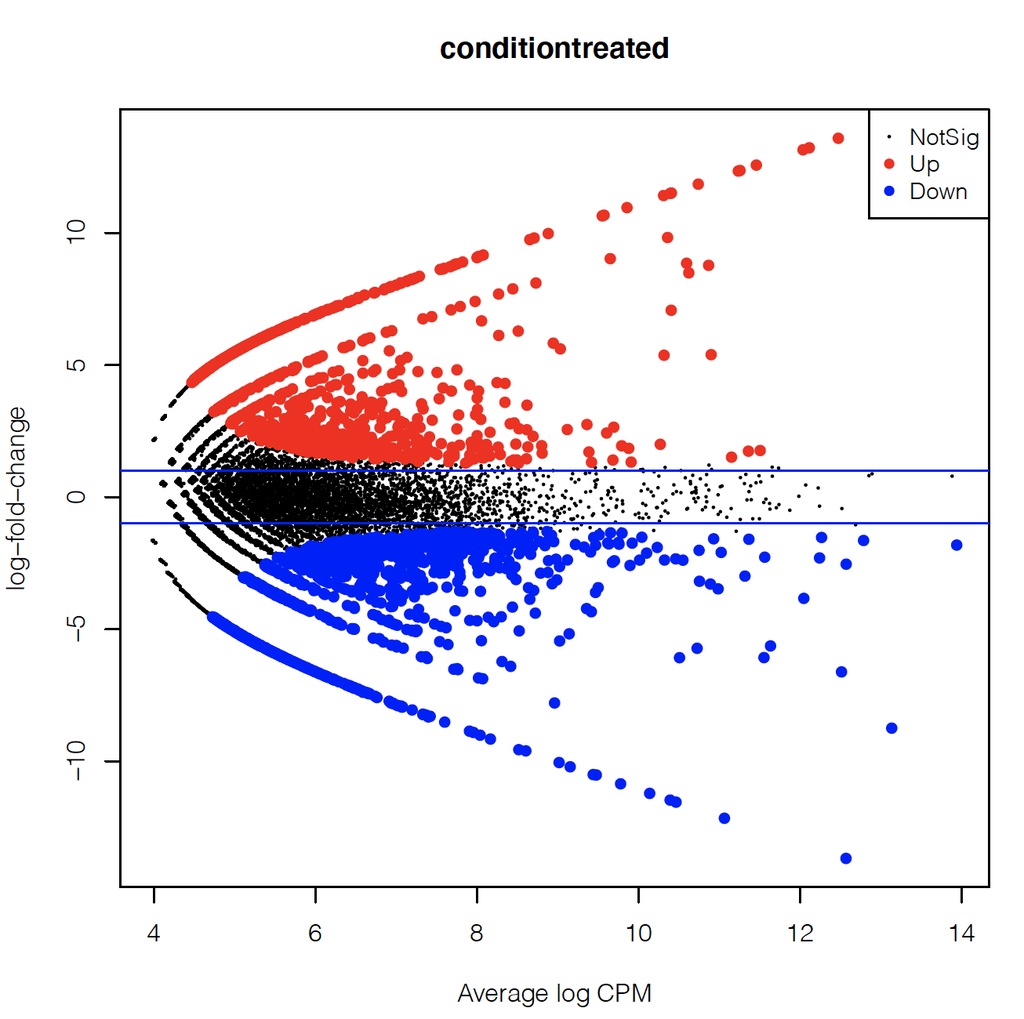

#### Folder with Differential Expression Analysis results

If you wish to look at the results of the Differential Expression Analysis in more details, you may explore the content of **de_analysis** sub-folder. For instance, here you may find the file with **DGE** results (e.g. for the downstream enrichment analysis). This file is called **results_dge.tsv**:

```
##                    logFC   logCPM        F       PValue          FDR
## ENSG00000163631 13.59090 12.47509 151.9144 7.345199e-35 1.023480e-30
## ENSG00000175899 13.23114 12.11580 148.7801 3.541862e-34 2.374083e-30
## ENSG00000167244 13.15371 12.03890 148.0493 5.111416e-34 2.374083e-30
```

Top genes with significant Differential Transcript Usage (**DTU**) are plotted in file **dtu_plots.pdf** file, which may look like this:

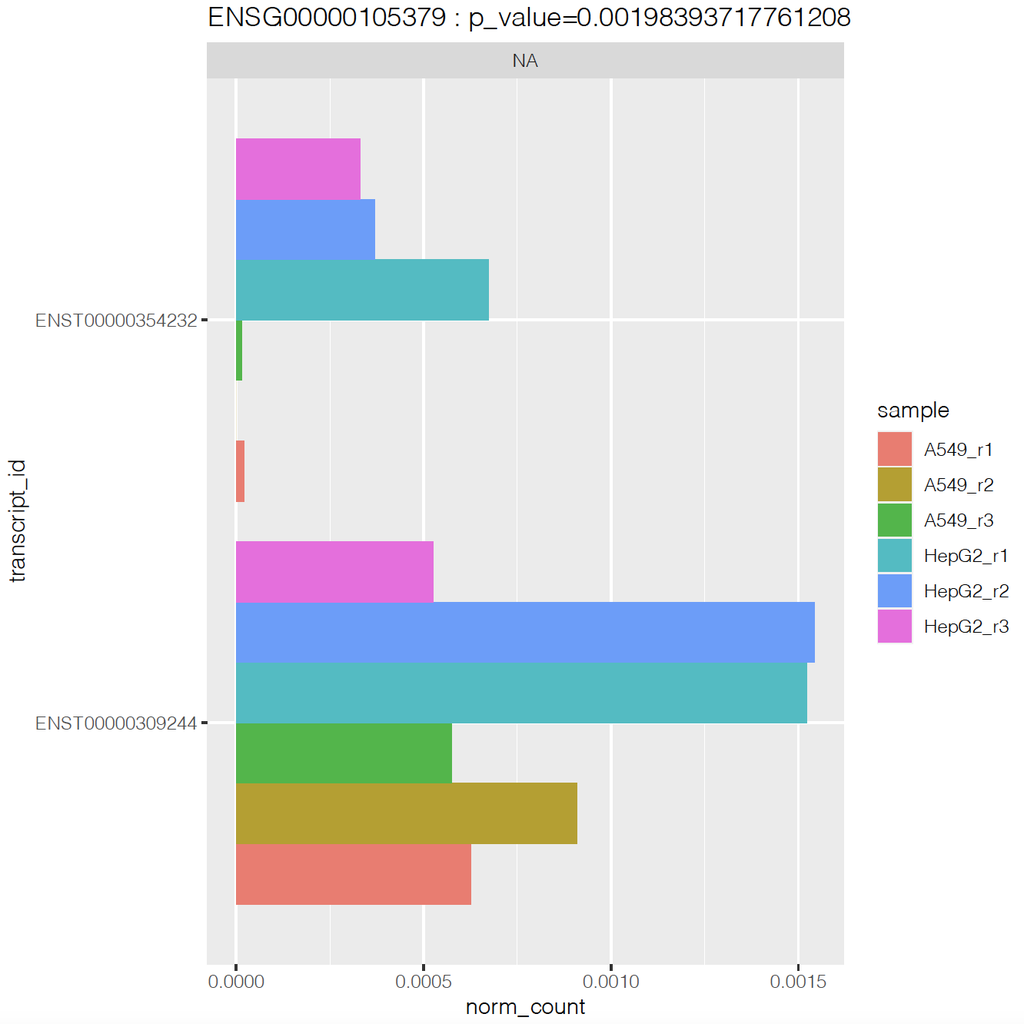

Find and explore pdf file with relevant plots generated in your analysis. What genes with Differential Transcript Usage (**DTU**) between **H9** and **HEYA8** cell lines have been detected? Can you recognize differentially used transcripts on the plots?

The results of **DTU** analysis are also provided in tab-separated text files **results_dtu_gene.tsv** and **results_dtu_transcript.tsv**:

```
##         featureID         groupID       pvalue
## 1 ENST00000533186 ENSG00000140988 2.637560e-16
## 2 ENST00000343262 ENSG00000140988 3.001444e-12
## 3 ENST00000309244 ENSG00000105379 7.122382e-07
```

Of course, these are only selected examples of **wf-transcriptomes** output: there are more files in the **de_analysis** sub-folder (and in the other sub-folders).

#### Nextflow summary report

If you are more interested in technical aspects of the run, you may look at the content of the sub-folder called **execution**. For instance, look in the **report.html** file within this folder:

[figure not shown]

# 6. Conclusion

This practical session was intended to give you a first-hand experience with **long-reads** RNA-seq data analysis.

First, you analysed Nanopore sequencing results given to you as FASTQ files (generated from *fast5* after basecalling):

- You performed selected steps for Nanopore QC and pre-processing (**NanoPlot**, **NanoComp**, **chopper**).
- Then you did a cDNA-specific step: selecting and orienting full-length RNAseq reads (**Pychopper**).

After this, you got an experience with running an entire **multi-step workflow**, provided by Nanopore for RNA-Seq **DGE** - **DTU** analyses as implemented in **wf-transcriptomes** pipeline.

The workflow illustrated

- conceptual continuity of **DGE** methods between *short-reads* and *long-reads* analyses (**minimap2**, **Salmon**, **edgeR**) and
- new opportunities provided by the *long-reads* that allow studying Differential Transcript Usage (**DTU**: **DEXSeq**, **stageR** )